# BANTER for Beaked Whales: South Atlantic

Shannon Rankin

2023-02-08

## PAMpal Data Processing

Start by loading the required packages

```r
library (PAMpal)
library(banter)
library(rfPermute)
library(kableExtra)
library(readxl)
library(stringr)
library(here)
here()
```

```
## [1] "C:/Users/shannon.rankin/Documents/GitHub/BANTER_BeakedWhales"
```

1. **Set up our PPS** (PAMPal Settings Object) for the satlantic dataset

```r
pps <- PAMpalSettings(db='Database/',
                      binaries = 'Binaries/',
                      sr_hz='auto',
                      winLen_sec=.0025,
                      filterfrom_khz=10,
                      filterto_khz=NULL)
```

2. **Process data** and save to file to eliminate repeated processing.

```r
data <- processPgDetections(pps, mode='db', id='satlantic_bw')
saveRDS(data, 'satlantic_study.rds')
# Double check warning messages
print(getWarnings(data)$message)
```

3. **Assign species identity** according to original PAMguard labels, then relabel for consistency across projects.

   *Final species ID for beaked whale detections was provided by A. DeAngelis as an excel spreadsheet. The following code chunk pulls out the required information (event, species) in the format required for PAMpal.*

```r
GU1605 <- read_excel("GU1605_PG_OfflineEvents_20210809.xlsx", sheet = "BWonly")#read in data
GU1605 <- filter(GU1605, !eventType == "BRAN")
#create formatted event/species dataframe
speciesID <- GU1605[c("Id", "Species", "Database")] %>%
  mutate("event" = paste(Database, Id, sep=".OE")) %>%
  rename("species" = "Species") %>%
  mutate("species" = str_replace_all(species, "'", ""),
         "species" = str_replace(species, "Sowerby", "Sowerbys"),
         "species" = str_replace(species, "Blainville", "Blainvilles"),
         "species" = str_replace(species, "Cuvier", "Cuviers")) %>%
  select(all_of(c("event", "species")))

#Assign species ID to data
data <- setSpecies(data, method='manual', value = speciesID)
#Note: 238 detections are not given species IDs and will be filtered out at a later step.
```

4. **Filter out unwanted data**: Subset and rename species for BANTER model

```r
goodSpecies<- c(c("Blainvilles", "Trues", "Cuviers", "Sowerbys", "Gervais"))
data <- filter(data, species %in% goodSpecies)
```

5. **Calculate Inter-Click Interval** (ICI).

```r
data <- calculateICI(data, time='peakTime')
```

6. **Export data for BANTER** (and drop species codes that will not be used for training). We will create two datasets: one with ICI and one without ICI, and save these for import into BANTER.

```r
banter_data <- export_banter(data, dropSpecies = 'unid',
                         dropVars = c('All_ici'), training=TRUE)
saveRDS(banter_data, file='satlantic_banter_data.rds')

banter_data_ici <- export_banter(data, dropSpecies = 'unid', training=TRUE)
saveRDS(banter_data_ici, file='satlantic_banter_data_ici.rds')

#save update of Acoustic Study
saveRDS(data, 'satlantic_study.rds')
```

## Build a BANTER Classification Model

### *Model without ICI*

1. Load data, initialize a BANTER model, and create an initial BANTER detector model (stage 1).

```r
banter_model <- initBanterModel(banter_data$events)
banter_model <- addBanterDetector(banter_model, banter_data$detectors, ntree=1e4, sampsize=2, importance = TRUE)
```

Check for stability (are more trees needed?) before moving on

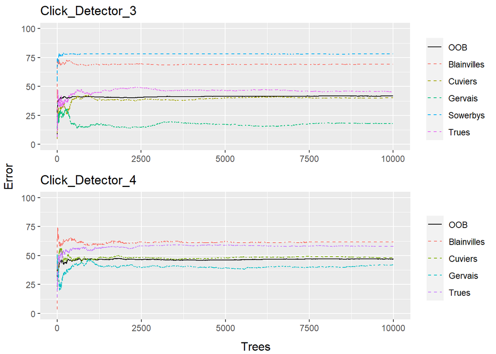

```r
plotDetectorTrace(banter_model, detector = paste0('Click_Detector_', 3:4))
```

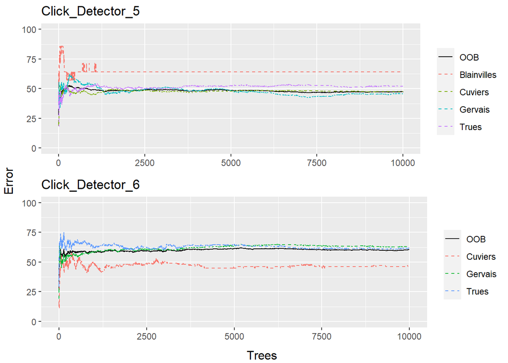

```r
plotDetectorTrace(banter_model, detector = paste0('Click_Detector_', 5:6))
```

```r
summary(banter_model)
```

[output not shown]

```
##
## << Summary for "event" model >>
```

```
##
## Number of trees: 1e+05
##
## Sample sizes:
## Blainvilles     Cuviers     Gervais    Sowerbys       Trues
##           1           1           1           1           1
##
## Distribution of percent correctly classified overall in last 50000 (50%) trees:
##    Min. 1st Qu.  Median    Mean 3rd Qu.    Max.
##   79.52   79.92   79.92   79.99   79.92   80.72
##
## Sample inbag proportion distribution:
##          Min. 1st Qu. Median Mean 3rd Qu. Max.
## expected  0.9     1.3    2.2 12.4     7.7 50.0
## observed  0.8     0.9    1.2  2.0     1.5 50.4
##
## Confusion matrix:
##             Blainvilles Cuviers Gervais Sowerbys Trues pct.correct  LCI_0.95
## Blainvilles          43       1       1        1     0    93.47826 82.103561
## Cuviers              18      80      10        2     1    72.07207 62.758567
## Gervais               1       4      62        1     9    80.51948 69.913285
## Sowerbys              1       0       0        1     0    50.00000  1.257912
## Trues                 0       0       0        0    13   100.00000 75.294736
## Overall              NA      NA      NA       NA    NA    79.91968 74.398576
##              UCI_0.95
## Blainvilles  98.63432
## Cuviers      80.17110
## Gervais      88.66683
## Sowerbys     98.74209
## Trues       100.00000
## Overall      84.71318
```

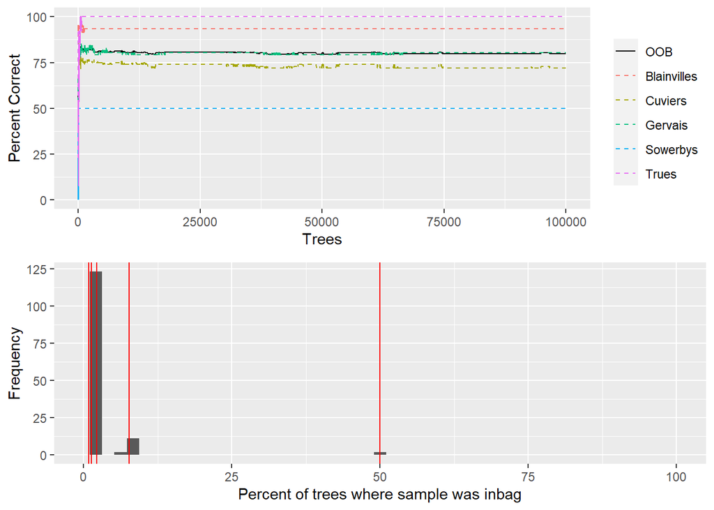

2. Run BANTER Event Model (stage 2)

```r
banter_model <- runBanterModel(banter_model, ntree=1e5, sampsize=1)
summary(banter_model)
```

```
## Model run times:
##                  start                 stop                  run.time
## Click_Detector_3 "2023-02-10 09:31:05" "2023-02-10 09:33:20" "2.24 mins"
## Click_Detector_4 "2023-02-10 09:33:20" "2023-02-10 09:33:47" "27.52 secs"
## Click_Detector_5 "2023-02-10 09:33:47" "2023-02-10 09:33:56" "8.81 secs"
## Click_Detector_6 "2023-02-10 09:33:56" "2023-02-10 09:33:57" "1.03 secs"
## event            "2023-02-10 09:50:49" "2023-02-10 09:51:02" "12.92 secs"
##
## Number of events and model classification rate:
##       species num.events Click_Detector_3 Click_Detector_4 Click_Detector_5
## 1 Blainvilles         46            69.24            61.67            64.29
## 2     Cuviers        111            40.38            48.13            47.72
## 3     Gervais         77            18.02            41.88            45.81
## 4    Sowerbys          2            78.17               NA               NA
## 5       Trues         13            45.59            57.94            52.12
## 6     Overall        249            41.81            47.01            47.47
##   Click_Detector_6  event
## 1               NA  93.48
## 2            47.00  69.37
## 3            63.37  80.52
## 4               NA  50.00
## 5            61.57 100.00
## 6            60.35  78.71
```

```
##
## << Summary for "event" model >>
```

```
##
## Number of trees: 1e+05
##
## Sample sizes:
## Blainvilles     Cuviers     Gervais    Sowerbys       Trues
##           1           1           1           1           1
##
## Distribution of percent correctly classified overall in last 50000 (50%) trees:
##    Min. 1st Qu.  Median    Mean 3rd Qu.    Max.
##   78.31   78.31   78.72   78.62   78.72   79.12
##
## Sample inbag proportion distribution:
##          Min. 1st Qu. Median Mean 3rd Qu. Max.
## expected  0.9     1.3    2.2 12.4     7.7 50.0
## observed  0.8     0.9    1.2  2.0     1.4 50.1
##
## Confusion matrix:
##             Blainvilles Cuviers Gervais Sowerbys Trues pct.correct  LCI_0.95
## Blainvilles          43       1       1        1     0    93.47826 82.103561
## Cuviers              21      77      10        2     1    69.36937 59.907397
## Gervais               1       4      62        1     9    80.51948 69.913285
## Sowerbys              1       0       0        1     0    50.00000  1.257912
## Trues                 0       0       0        0    13   100.00000 75.294736
## Overall              NA      NA      NA       NA    NA    78.71486 73.101655
##              UCI_0.95
## Blainvilles  98.63432
## Cuviers      77.76733
## Gervais      88.66683
## Sowerbys     98.74209
## Trues       100.00000
## Overall      83.63048
```

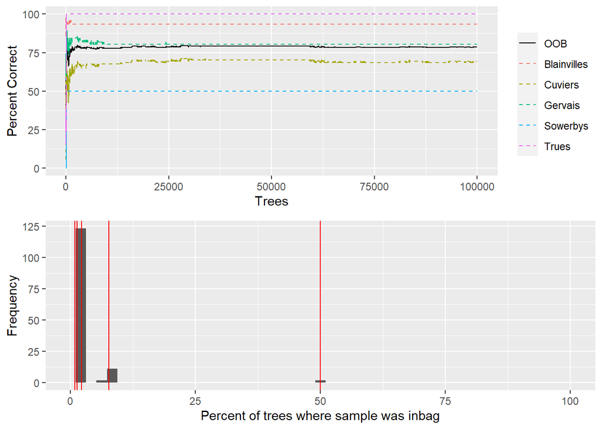

Check for stability (are more trees needed?). If acceptable, save model with tree/sampsize info in the filename.

```r
saveRDS(banter_model, 'satlantic_banter_model_t1e4s2_t1e5s1.rds')
```

### *ICI Model*

1. Load data, initialize a BANTER model, and create an initial BANTER detector model (stage 1).

```r
banter_model_ici <- initBanterModel(banter_data_ici$events)
banter_model_ici <- addBanterDetector(banter_model_ici, banter_data_ici$detectors, ntree=1e4, sampsize=4, importance = TRUE)
```

Check for stability to see if we need more trees

[figure not shown]

```r
plotDetectorTrace(banter_model, detector = paste0('Click_Detector_', 3:4))
```

[figure not shown]

```r
plotDetectorTrace(banter_model, detector = paste0('Click_Detector_', 5:6))
```

```r
summary(banter_model_ici)
```

[output not shown]

```
##
## << Summary for "event" model >>
```

```
##
## Number of trees: 1e+05
##
## Sample sizes:
## Blainvilles     Cuviers     Gervais    Sowerbys       Trues
##           1           1           1           1           1
##
## Distribution of percent correctly classified overall in last 50000 (50%) trees:
##    Min. 1st Qu.  Median    Mean 3rd Qu.    Max.
##   87.15   87.15   87.55   87.35   87.55   87.55
##
## Sample inbag proportion distribution:
##          Min. 1st Qu. Median Mean 3rd Qu. Max.
## expected  0.9     1.3    2.2 12.4     7.7 50.0
## observed  0.8     0.9    1.3  2.0     1.4 50.1
##
## Confusion matrix:
##             Blainvilles Cuviers Gervais Sowerbys Trues pct.correct  LCI_0.95
## Blainvilles          43       1       1        1     0    93.47826 82.103561
## Cuviers              10      89       9        2     1    80.18018 71.544669
## Gervais               0       1      72        0     4    93.50649 85.493334
## Sowerbys              1       0       0        1     0    50.00000  1.257912
## Trues                 0       0       0        0    13   100.00000 75.294736
## Overall              NA      NA      NA       NA    NA    87.55020 82.796007
##              UCI_0.95
## Blainvilles  98.63432
## Cuviers      87.14239
## Gervais      97.85813
## Sowerbys     98.74209
## Trues       100.00000
## Overall      91.38196
```

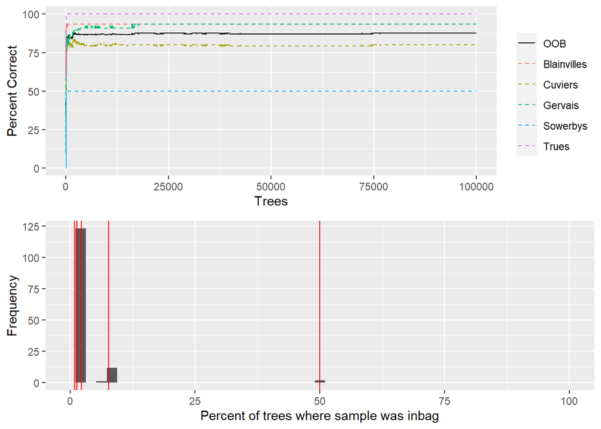

2. Run BANTER Event Model (stage 2)

```r
banter_model_ici <- runBanterModel(banter_model_ici, ntree=1e5, sampsize=1)
summary(banter_model_ici)
```

```
## Model run times:
##                  start                 stop                  run.time
## Click_Detector_3 "2023-02-10 09:43:49" "2023-02-10 09:47:09" "3.33 mins"
## Click_Detector_4 "2023-02-10 09:47:09" "2023-02-10 09:47:53" "44.24 secs"
## Click_Detector_5 "2023-02-10 09:47:53" "2023-02-10 09:48:07" "14.04 secs"
## Click_Detector_6 "2023-02-10 09:48:07" "2023-02-10 09:48:09" "1.61 secs"
## event            "2023-02-10 09:51:11" "2023-02-10 09:51:24" "12.95 secs"
##
## Number of events and model classification rate:
##       species num.events Click_Detector_3 Click_Detector_4 Click_Detector_5
## 1 Blainvilles         46            68.03            63.33            71.43
## 2     Cuviers        111            40.91            47.44            47.89
## 3     Gervais         77            19.48            54.13            52.83
## 4    Sowerbys          2            78.17               NA               NA
## 5       Trues         13            49.64            60.77            49.76
## 6     Overall        249            42.50            50.59            49.98
##   Click_Detector_6  event
## 1               NA  93.48
## 2            51.00  81.08
## 3            59.30  93.51
## 4               NA  50.00
## 5            74.38 100.00
## 6            63.41  87.95
```

```
##
## << Summary for "event" model >>
```

```
##
## Number of trees: 1e+05
##
## Sample sizes:
## Blainvilles     Cuviers     Gervais    Sowerbys       Trues
##           1           1           1           1           1
##
## Distribution of percent correctly classified overall in last 50000 (50%) trees:
##    Min. 1st Qu.  Median    Mean 3rd Qu.    Max.
##   87.95   87.95   87.95   87.95   87.95   87.95
##
## Sample inbag proportion distribution:
##          Min. 1st Qu. Median Mean 3rd Qu. Max.
## expected  0.9     1.3    2.2 12.4     7.7 50.0
## observed  0.8     0.9    1.3  2.0     1.4 50.3
##
## Confusion matrix:
##             Blainvilles Cuviers Gervais Sowerbys Trues pct.correct  LCI_0.95
## Blainvilles          43       1       1        1     0    93.47826 82.103561
## Cuviers               9      90       9        2     1    81.08108 72.546141
## Gervais               0       1      72        0     4    93.50649 85.493334
## Sowerbys              1       0       0        1     0    50.00000  1.257912
## Trues                 0       0       0        0    13   100.00000 75.294736
## Overall              NA      NA      NA       NA    NA    87.95181 83.248977
##              UCI_0.95
## Blainvilles  98.63432
## Cuviers      87.89069
## Gervais      97.85813
## Sowerbys     98.74209
## Trues       100.00000
## Overall      91.72159
```

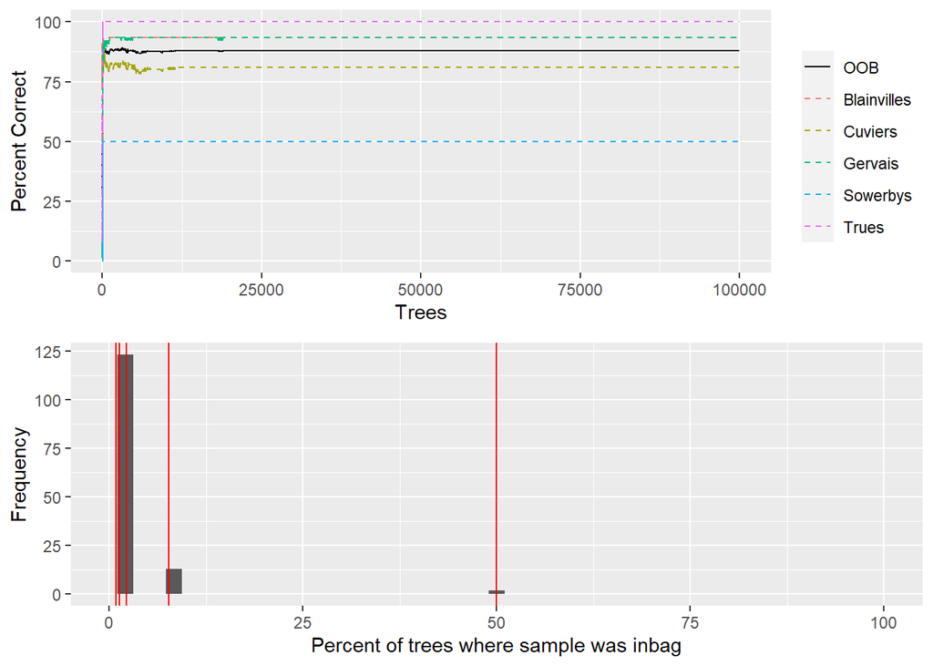

Check for stability (are more trees needed?). If acceptable, save model with tree/sampsize info in the filename.

```r
saveRDS(banter_model_ici, 'satlantic_banter_model_ici_t1e4s4_t1e5s1.rds')
```

## BANTER Analytics

There are a number of visualizations/data products that allow us to visualize our BANTER classifier; most use the rfPermute package (see [BANTER Guidelines](https://taikisan21.github.io/PAMpal/banterGuide.html) for more information)

First, identify the model you would like to examine (comment out the model you do not want to examine).

```r
model <- banter_model
modelname <- "banter_model"

model_ici <- banter_model_ici
modelname_ici <- "banter_model_ici"
```

Extract the Random Forest model object from our BANTER model for analysis.

```r
banter_model_RF <- getBanterModel(model)
banter_model_ici_RF <- getBanterModel(model_ici)
```

Confusion Matrix (simple model)

```r
satlantic_confuseMatrix <- rfPermute::confusionMatrix(banter_model_RF)
satlantic_confuseMatrix <- kable(satlantic_confuseMatrix, align = "c", digits = c(0,0,0,0,2,2,2))%>%
  kable_classic()%>%
  column_spec(4, border_right = TRUE)%>%
  row_spec(0, bold = TRUE)%>%
  row_spec(3,hline_after = TRUE)%>%
  row_spec(4, bold = TRUE)%>%
  save_kable(paste(modelname, "satlantic_confuseMatrix.png", sep="_"), zoom = 2)
```

```
## save_kable will have the best result with magick installed.
```

```r
satlantic_ici_confuseMatrix <- rfPermute::confusionMatrix(banter_model_ici_RF)
satlantic_ici_confuseMatrix <- kable(satlantic_ici_confuseMatrix, align = "c", digits = c(0,0,0,0,2,2,2))%>%
  kable_classic()%>%
  column_spec(4, border_right = TRUE)%>%
  row_spec(0, bold = TRUE)%>%
  row_spec(3,hline_after = TRUE)%>%
  row_spec(4, bold = TRUE)%>%
  save_kable(paste(modelname_ici, "satlantic_ici_confuseMatrix.png", sep="_"), zoom = 2)
```

```
## save_kable will have the best result with magick installed.
```

[figure not shown]

Proximity Plot

```r
png(paste(modelname, "satlantic_proximity.png", sep="_"), width = 20, height = 20, units = 'cm', res = 300)
satlantic_proximityPlot <- plotProximity(banter_model_RF)
```

```
## Too few points to calculate an ellipse
```

```r
dev.off()
```

```
## Too few points to calculate an ellipse
```

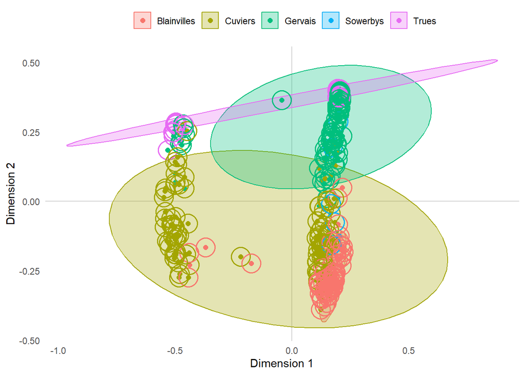

```r
satlantic_proximityPlot <- plotProximity(banter_model_RF)
```

```r
png(paste(modelname_ici, "satlantic_proximity.png", sep="_"), width = 20, height = 20, units = 'cm', res = 300)
ici_satlantic_proximityPlot <- plotProximity(banter_model_ici_RF)
```

```
## Too few points to calculate an ellipse
```

```r
dev.off()
```

```
## Too few points to calculate an ellipse
```

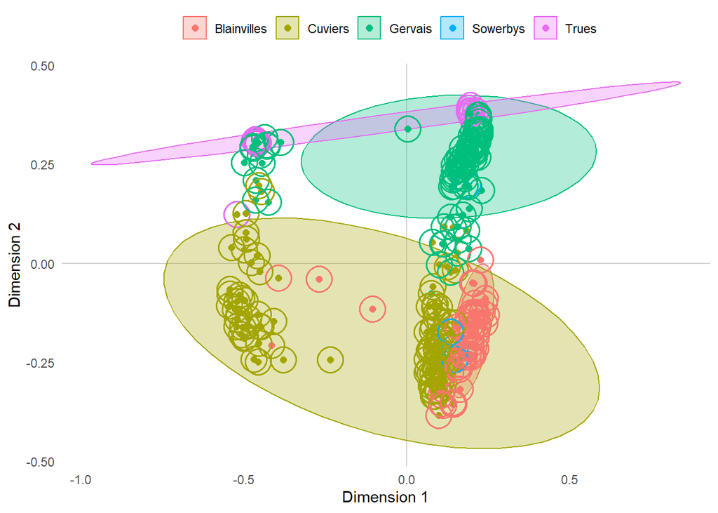

```r
ici_satlantic_proximityPlot <- plotProximity(banter_model_ici_RF)
```

Importance Heatmap

```r
png(paste(modelname, "satlantic_importance.png", sep="_"), width = 30, height = 25, units = 'cm', res = 300)
plotImportance(banter_model_RF, plot.type="heatmap")
dev.off()
```

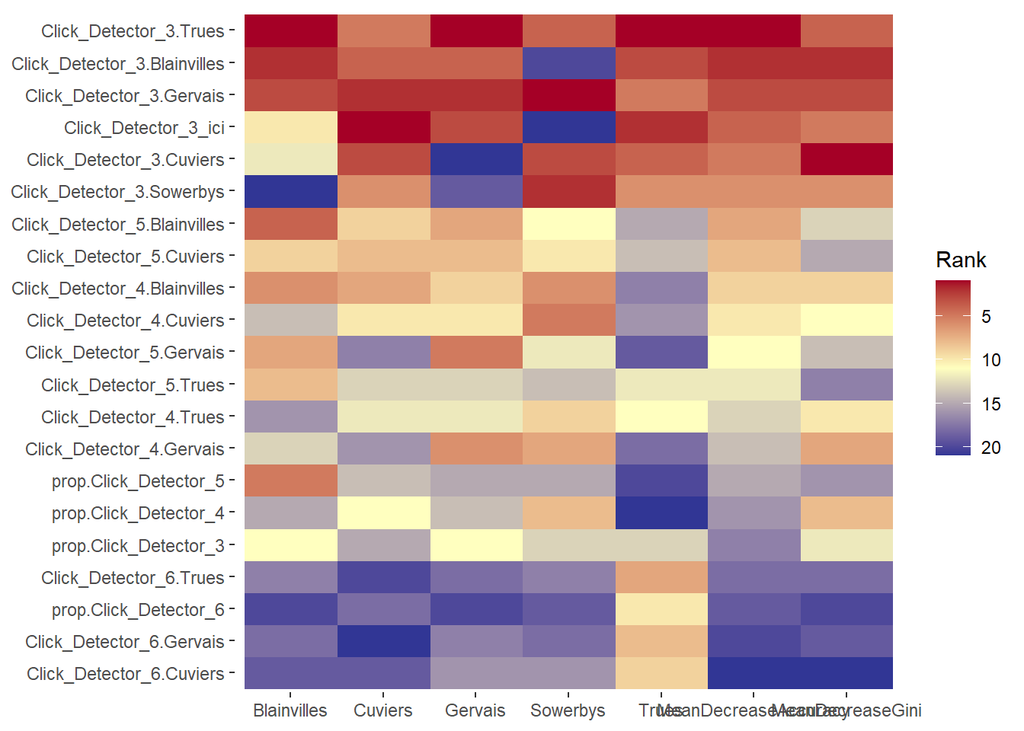

```r
satlantic_importance <- plotImportance(banter_model_RF, plot.type="heatmap")
```

```r
png(paste(modelname_ici, "satlantic_importance.png", sep="_"), width = 30, height = 25, units = 'cm', res = 300)
plotImportance(banter_model_ici_RF, plot.type="heatmap")
dev.off()
```

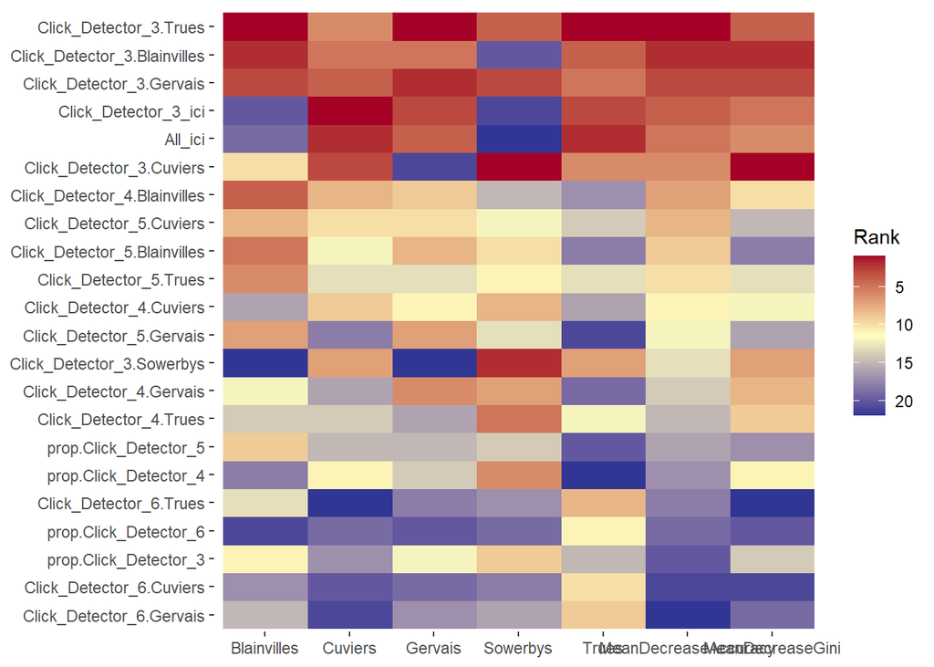

```r
ici_satlantic_importance <- plotImportance(banter_model_ici_RF, plot.type="heatmap")
```

PlotVotes

```r
png(paste(modelname, "satlantic_votes.png", sep="_"), width = 20, height = 20, units = 'cm',  res = 300)
plotVotes(banter_model_RF)
dev.off()
```

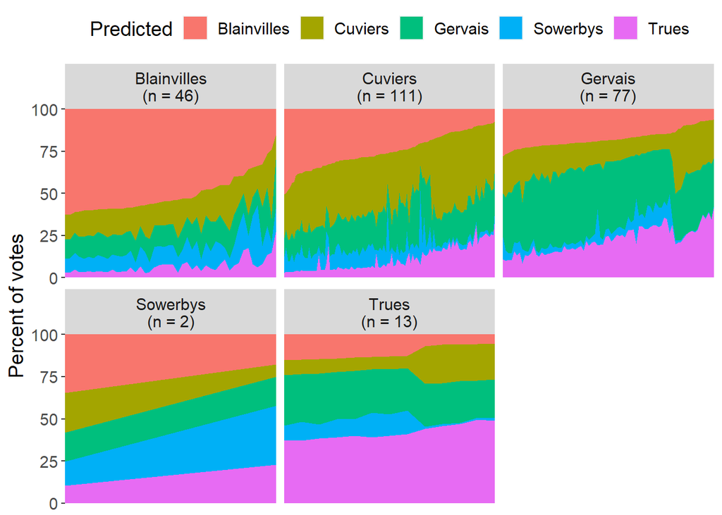

```r
satlantic_votes <- plotVotes(banter_model_RF)
```

```r
png(paste(modelname_ici, "satlantic_votes.png", sep="_"), width = 20, height = 20, units = 'cm',  res = 300)
plotVotes(banter_model_ici_RF)
dev.off()
```

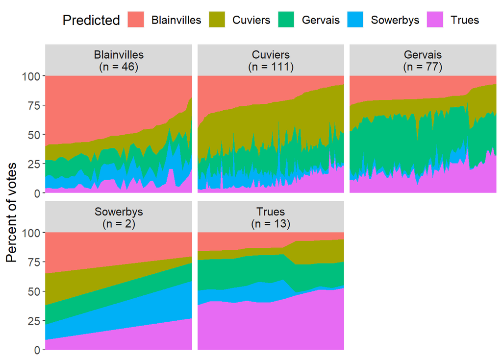

```r
ici_satlantic_votes <- plotVotes(banter_model_ici_RF)
```

Class Priors (Expected Error Rate)

```r
satlantic_priors <- classPriors(banter_model_RF, NULL)
```

Plot Confusion Matrix Heat Map

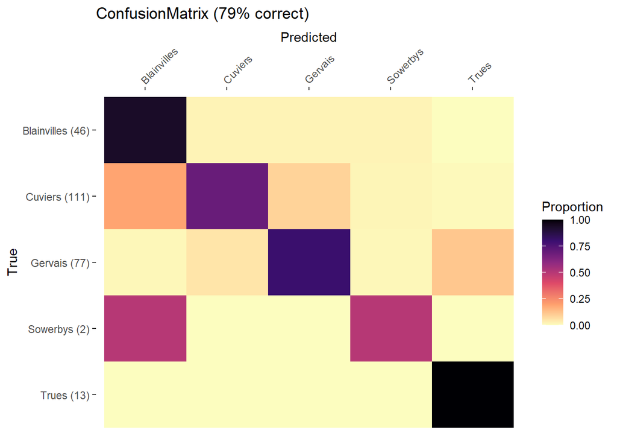

```r
plotConfMat(banter_model_RF, title="ConfusionMatrix", plot=TRUE)
```

Plot Error Trace for Banter Model

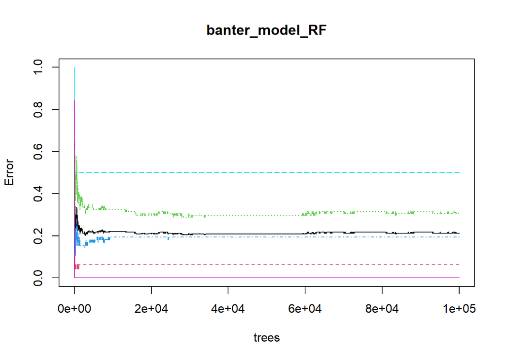

```r
plot(banter_model_RF)
```

Plot Predicted Probabilities

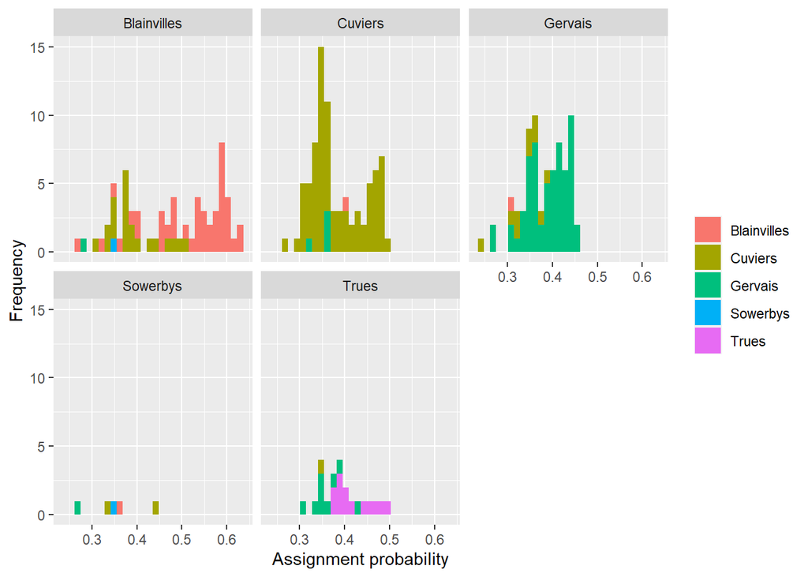

```r
plotPredictedProbs(banter_model_RF, bins=30, plot=TRUE)
```